# William Murphy, M.S., R.D.N.

| Data Visualization Expert | ◈ | Data Scientist | ◈ | Clinical Researcher |
| --- | --- | --- | --- | --- |

| william@datatitian.com | Chicago, IL | https://www.linkedin.com/in/wmurphyrd |
| --- | --- | --- |

## Professional Appointments

[output not shown]

## Training and Education

### Degrees

| M.S., Nutrition | Case Western Reserve University | Cleveland, OH |  | 2011 |
| --- | --- | --- | --- | --- |
| B.S., Nutrition | University of New Mexico | Albuquerque, NM |  | 2009 |

### Certifications and Professional Development

[output not shown]

## Publications, Presentations, Grants, and Products

Selected items (complete listing available at [wmurphyrd.github.io/resume](http://wmurphyrd.github.io/resume/))

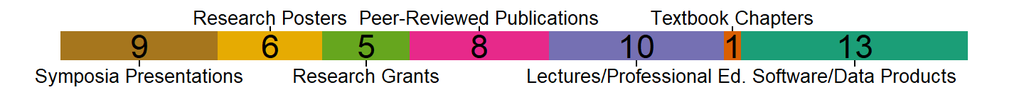

### Software/Data Products

How to Turn Your ggplot2 Visualization into an Interactive Tweet with plot.ly. [Available at datatitian.com](https://datatitian.com/how-to-turn-your-ggplot2-visualization-into-an-interactive-tweet/)

A-Frame Machinima Testing: automated functional testing for WebVR virtual reality projects using motion-captured user input with Karma, Mocha, & Chai. [Available at npmjs.org](https://www.npmjs.com/package/aframe-machinima-testing)

### Peer-Reviewed Publications

Murphy WJ, Yadrick MM, Steiber AL, Mohan V, Papoutsakis C. Academy of Nutrition and Dietetics Health Informatics Infrastructure (ANDHII): A Pilot Study on the Documentation of the Nutrition Care Process and the Usability of ANDHII by Registered Dietitian Nutritionists. J Acad Nutr Diet. 2018 Oct;118(10):1966-1974.

### Symposia Presentations

Cultivating Research Skills: Working with your IRB and Getting started with De-Identified Data. 2016 Food & Nutrition Conference & Expo. Boston, MA.

### Textbook Chapters

Murphy W, Hand RK. Outcomes Research and Economic Analysis. In: Van Horn L, Beto J, eds. Research: Successful Approaches in Nutrition and Dietetics. 4th ed. Chicago, IL: Academy of Nutrition and Dietetics; 2019:350-379.

Created with knitr. Source available at http://github.com/wmurphyrd/resume